# Assignment 2

Please read the following instructions carefully:

This assignment will test your knowledge of machine learning, data visualisation, and computer vision techniques in Python. This will primarily focus on scikit-learn, seaborn/matplotlib and skimage/opencv, and how to program using these packages and as such you should use the appropriate functionality provided by the packages. You may also use Numpy, panda, etc. where appropriate for some questions. Do not use any other external packages other than these.

In the below questions you will generally need to complete the code in the cell below the question and output the required results, charts or graphs.

Questions 1-5 are each worth 5 marks.

#### 1. Load/download and normalize the FashionMNIST training and test datasets using the instructions shown here: https://github.com/zalandoresearch/fashion-mnist#usage.

#### Please download both the training and testing sets, and load the training images, training labels, testing images, and testing labels as 'x_train', 'y_train', 'x_test', and 'y_test, correspondingly.

#### And show some training images by visualising a few images from the training set.

```python
# Importing the FashionMNIST data following GitHub instructions --------
import numpy as np
import mnist_reader

X_train, y_train = mnist_reader.load_mnist('data', kind='train')
X_test, y_test = mnist_reader.load_mnist('data', kind='t10k')
```

```python
# quick exploration of our data
print(f"X_train:- dtype: {type(X_train)}, max: {X_train.max()}, min: {X_train.min()}, shape: {X_train.shape}")
print(f"y_train:- dtype: {type(y_train)}, max: {y_train.max()}, min: {y_train.min()}, shape: {y_train.shape}")
print(f"X_test:- dtype: {type(X_test)}, max: {X_test.max()}, min: {X_test.min()}, shape: {X_test.shape}")
print(f"y_test:- dtype: {type(y_test)}, max: {y_test.max()}, min: {y_test.min()}, shape: {y_test.shape}")
```

```
X_train:- dtype: <class 'numpy.ndarray'>, max: 255, min: 0, shape: (60000, 784)
y_train:- dtype: <class 'numpy.ndarray'>, max: 9, min: 0, shape: (60000,)
X_test:- dtype: <class 'numpy.ndarray'>, max: 255, min: 0, shape: (10000, 784)
y_test:- dtype: <class 'numpy.ndarray'>, max: 9, min: 0, shape: (10000,)
```

From the data information above, we have 60,000 training images and 10,000 test images, each with 784 pixels or features (originally in a 28*28 dimention) whose values range from 0 (black) to 255 (white). The labels data is one dimentional, containing a 0-9 label for each image, which corresponds to each article of clothing.

### Data Preprocessing:

It is essential to perform feature scaling on the input data prior to model fitting to ensure acurate performance as the values are read by the chosen ML model and to help increase the speed of analysis. This is especially important when the units of your different features are not comparable (in our case however, all of our features are pixel values of roughly the same range 0-255). Here, two data transformation methods will be examined and their performace compared: standardization and normalization. Using `norm = 'max'` as our argument, out normalization function below will scale the data between 0 and 1 while the standardization function will center the data around an average of 0 and a standard deviation of 1.

```python
#-------- Apply different types of data transformation on X_train and X_test ------
from sklearn.preprocessing import StandardScaler
from sklearn.preprocessing import Normalizer

# 1. using StandardScaler()
X_train_Scaled = StandardScaler().fit_transform(X_train)
X_test_Scaled = StandardScaler().fit_transform(X_test)

# 2. using Normalizer()
X_train_Norm = Normalizer(norm = 'max').fit_transform(X_train)
X_test_Norm = Normalizer(norm = 'max').fit_transform(X_test)
```

```
Investigating data transformation for feature #402:
X_train (original) -- min: 0, max: 255
X_train_Scaled ------ mean: 0.0, standard deviation: 1.0
X_train_Norm -------- min: 0.0, max: 1.0


Distribution of values for feature #402 before and after normalization. Notice the differences in values on the x-axis:
```

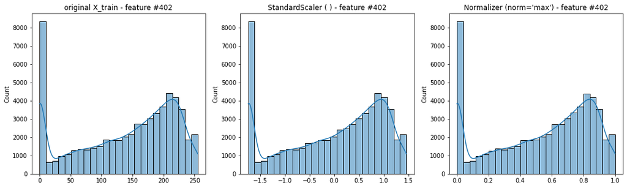

```python
#---------investigating a random column-----------#
import matplotlib.pyplot as plt
import seaborn as sns

feature = 402 # choose a random column between 0-783

print(f"Investigating data transformation for feature #{feature}:")
print(f"X_train (original) -- min: {X_train[:,feature].min()}, max: {X_train[:,feature].max()}")
print(f"X_train_Scaled ------ mean: {round(X_train_Scaled[:,feature].mean(),1)}, standard deviation: {round(X_train_Scaled[:,feature].std(),1)}")
print(f"X_train_Norm -------- min: {X_train_Norm[:,feature].min()}, max: {X_train_Norm[:,feature].max()}\n")

# investigate distribution of feature values
print(f"\nDistribution of values for feature #{feature} before and after normalization. Notice the differences in values on the x-axis:")
fig, axes = plt.subplots(1, 3, figsize=(18,5))
sns.histplot(X_train[:,feature],        kde=True, bins = 25, ax=axes[0]).set(title = f"original X_train - feature #{feature}")
sns.histplot(X_train_Scaled[:,feature], kde=True, bins = 25, ax=axes[1]).set(title = f"StandardScaler ( ) - feature #{feature}")
sns.histplot(X_train_Norm[:,feature],   kde=True, bins = 25, ax=axes[2]).set(title = f"Normalizer (norm='max') - feature #{feature}")
plt.show()
```

```python
import skimage

# create the y-label dictionary to be used in the function below
labels = {0 : "T-shirt/top",
          1 : "Trouser",
          2 : "Pullover",
          3 : "Dress",
          4 : "Coat",
          5 : "Sandal",
          6 : "Shirt",
          7 : "Sneaker",
          8 : "Bag",
          9 : "Ankle boot"}

# creating a function to display randomly selected images as subplots with custom titles
def display_samples(num_images, X_dataset, title='row', y_dataset=None, y_predicted=None):
    '''
    Create a plot with a user given number of subplots which displays randomly selected
    images from the given 2D numpy array dataset. This function also creates custom titles.

    Parameters
    ----------
    num_images: int
        How many random images to show

    X_dataset: 2D numpy array
        The dataset from which to choose random images. Could be X_train or X_test.

    title: string
        'row' (default) to use the randomly selected row number as the subplot title
        'true_label' to use the labels from the user-given y_dataset as the subplot title. Must correspond to X_dataset.
        'predicted_label' to use the 'predicted_label(true_label)' format as the subplot title

    y_dataset: 1D array
        The dataset containing the true labels. Could be y_train or t_test. Must be the same length as X_dataset.shape[0]

    y_predicted: 1D array
        The dataset containing the predicted labels. Must be the same length as X_dataset.shape[0]
    '''

    # create 'num_images' subplots
    figures, axes = plt.subplots(1, num_images, figsize=(13, 13))
    ax = axes.ravel()

    # select 'num_images' random rows/images from X_dataset and save selected row numbers in a list called 'row'
    # iterating 'num_images' times, select a random number between all possible row indices from X_dataset
    row = list(np.random.randint(0,X_dataset.shape[0]-1) for i in range(num_images))

    for i in range(num_images): # for every image selected above..
        # ..reshape the row into it's 2D form and convert to greyscale
        ax[i].imshow(X_dataset[row[i]].reshape(28,28), cmap = 'gray')

        # for the title..
        if title == 'row':
            ax[i].set_title(f"Image #{row[i]}") # .. set the plot title from the row number

        elif title == 'true_label':
            key = y_dataset[row[i]] # ..get the corresponding y-label from the user-given y_dataset (an integer from 0-9)..
            ax[i].set_title(f"{labels[key]}") # ..and get the title from the label dictionary

        elif title == 'predicted_label':
            key_actual = y_dataset[row[i]] # ..get the corresponding true y-label which is an integer from 0-9..
            key_predicted = y_predicted[row[i]] # ..and the corresponding predicted y-label..
            ax[i].set_title(f"{labels[key_predicted]}({labels[key_actual]})") # ..and get the title from the label dictionary

    figures.tight_layout()
    plt.show()
```

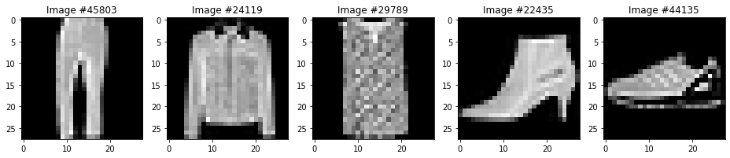

```python
# use the image display function above to show 5 random X_train images and use the row numbers as titles
display_samples(5, X_train, title='row')
```

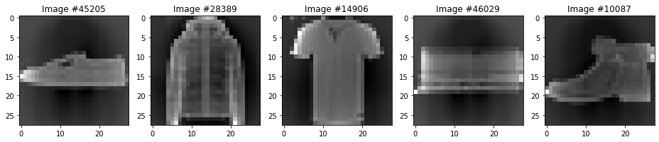

```python
# use the image display function to show 5 random X_train_Scaled images and use the row numbers as titles
display_samples(5, X_train_Scaled, title='row')
```

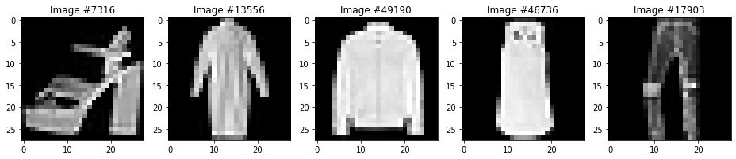

```python
# use the image display function to show 5 random X_train_Norm images and use the row numbers as titles
display_samples(5, X_train_Norm, title='row')
```

- As we can notice from the images above, the **normalized** data does not seem to differ from the original data. This is because the normalization transformation retained the relative distances between the different values since all features shared the same fixed range of 0-255 and simply shifted the range of values from 0-255 to 0-1 as we saw in the histogram plot earlier. However, this might still help increase the speed of the training process.
- As for the **standardized** data, we can see that the images generally look different than the original ones. This is because it computes the average pixel value of each feature individually and uses that, along with it's standard deviation, to rescale that feature without any specific min/max value to adhere to.

#### 2. Please show 5 images from the training set in a row (similar to what you have done above), but this time also show the corresponding category name (e.g. T-shirt, Dress, Bag, etc., detailed definition of the categories is list on the dataset link above) on top of each image as its title.

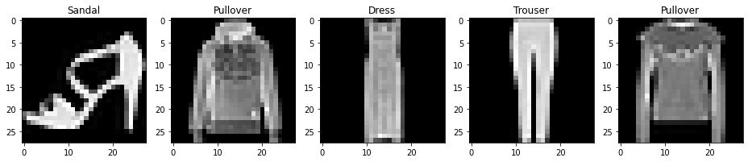

```python
# set title to 'true_label' and provide y_train from which to print the labels
display_samples(5, X_train, title='true_label', y_dataset = y_train)
```

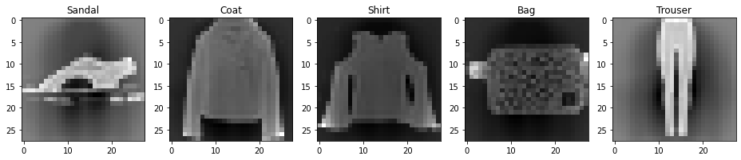

```python
# set title to 'true_label' and provide y_train from which to print the labels
display_samples(5, X_train_Scaled, title='true_label', y_dataset = y_train)
```

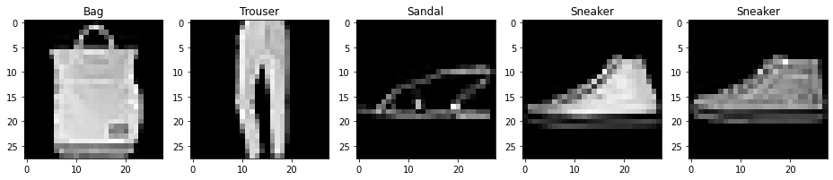

```python
# set title to 'true_label' and provide y_train from which to print the labels
display_samples(5, X_train_Norm, title='true_label', y_dataset = y_train)
```

#### 3. Apply a support vector classifier on the above (training) data. And use the learned/trained classifier to predict the category value on the test set.

#### The parameters to be used in the SVM classifier are: linear kernel, regularization of 0.025, and all others by default.

#### If you find the training over the whole training set takes too much time (e.g. > 10 minutes), you may only use the first 10,000 samples of the training set instead.

#### Please also show 5 examples from the test set, with the title being "predicted category name (ground-truth category name)", e.g. "Shirt (Shirt)".

```python
%%time
# measure the amount of time needed to process the cell

from sklearn.svm import SVC

# time the data training process, set the number of loops and runs to 1 each
# apply a support vector classifier with linear kernel and regularization of 0.025
# fit the model to the training data (only the first 10,000 rows)
# predict labels using X_test then perform a quick accuracy check


# apply svc on original X_train data
%timeit -n1 -r1 my_svc = SVC(kernel="linear", C=0.025).fit(X_train[:10000, :], y_train[:10000])
y_predicted_svc = my_svc.predict(X_test)
print(f"Our SVC prediction using X_train is {np.sum((y_test == y_predicted_svc))/100}% accurate using 10,000 training samples.\n")


# apply svc on X_train_Scaled data
%timeit -n1 -r1 my_svc_Scaled = SVC(kernel="linear", C=0.025).fit(X_train_Scaled[:10000, :], y_train[:10000])
y_predicted_svc_Scaled = my_svc_Scaled.predict(X_test_Scaled)
print(f"Our SVC prediction using X_train_Scaled is {np.sum((y_test == y_predicted_svc_Scaled))/100}% accurate using 10,000 training samples.\n")


# apply svc on X_train_Norm data
%timeit -n1 -r1 my_svc_Norm = SVC(kernel="linear", C=0.025).fit(X_train_Norm[:10000, :], y_train[:10000])
y_predicted_svc_Norm = my_svc_Norm.predict(X_test_Norm)
print(f"Our SVC prediction using X_train_Norm is {np.sum((y_test == y_predicted_svc_Norm))/100}% accurate using 10,000 training samples.\n")
```

```
55.4 s ± 0 ns per loop (mean ± std. dev. of 1 run, 1 loop each)
Our SVC prediction using X_train is 79.64% accurate using 10,000 training samples.

14.9 s ± 0 ns per loop (mean ± std. dev. of 1 run, 1 loop each)
Our SVC prediction using X_train_Scaled is 83.29% accurate using 10,000 training samples.

15.8 s ± 0 ns per loop (mean ± std. dev. of 1 run, 1 loop each)
Our SVC prediction using X_train_Norm is 83.85% accurate using 10,000 training samples.

CPU times: total: 1min 10s
Wall time: 2min 42s
```

We can see from the initial results above that the transformed data leads to a more accurate training of the svc model compared to when we trained the same model using the original dataset. Furthermore, the accuracy from both the normalized and standardized data are comparable.

**note:** the cells containing code for model fitting thoughout this notebook were run first without the in-line %timeit function since the variables couldn't be saved after time computation. `%timeit` was then added and code run again to avoid NameError. `-n1 -r1` were specified for faster code execution.

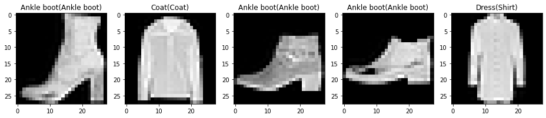

```python
# show 5 examples of images from X_test for SVC
display_samples(5, X_test, title='predicted_label', y_dataset = y_test, y_predicted = y_predicted_svc)
```

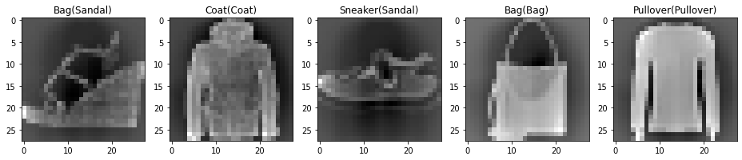

```python
# show 5 examples of images from X_test_Scaled for SVC
display_samples(5, X_test_Scaled, title='predicted_label', y_dataset = y_test, y_predicted = y_predicted_svc_Scaled)
```

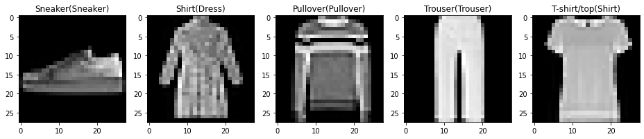

```python
# show 5 examples of images from X_test_Norm for SV
display_samples(5, X_test_Norm, title='predicted_label', y_dataset = y_test, y_predicted = y_predicted_svc_Norm)
```

#### 4. Similar to above, but use a neural network (i.e. MLP classifier) for the classification task, and training it for 1000 maximum number of iterations, with the L2 penalty of 1.

#### First use the same 10,000 training samples, then change the number of training samples to the whole training set. Think about the difference between this classifier and the above SVM classifier.

#### Please also show 5 samples from the test set (same as above), and also print the text report of the main classification metrics. Think about how does it differ from the results in the above SVM classification model (i.e. you need to print out the classification metrics for the above SVM model to compare).

#### 1. MLP using 10,000 images

```python
%%time
# measure the amount of time needed to process the cell

from sklearn.neural_network import MLPClassifier

# apply a neural network classifier, namely the MLP, with a maximum of 1000 iterations and an L2 penalty of 1
# and use the first 10,000 images (10k) then fit the model to the training data (first 10,000 rows only)
# and retrieve the predicted labels then perform a quick accuracy check


# apply on original data
%timeit -n1 -r1 my_mlp_10k = MLPClassifier(alpha=1, max_iter=1000).fit(X_train[:10000, :], y_train[:10000])
y_predicted_mlp_10k = my_mlp_10k.predict(X_test)
print(f"Our MLP prediction using X_train is {np.sum((y_test == y_predicted_mlp_10k))/100}% accurate using 10,000 training samples.\n")


# apply on X_train_Scaled data
%timeit -n1 -r1 my_mlp_10k_Scaled = MLPClassifier(alpha=1, max_iter=1000).fit(X_train_Scaled[:10000, :], y_train[:10000])
y_predicted_mlp_10k_Scaled = my_mlp_10k_Scaled.predict(X_test_Scaled)
print(f"Our MLP prediction using X_train_Scaled is {np.sum((y_test == y_predicted_mlp_10k_Scaled))/100}% accurate using 10,000 training samples.\n")


# apply on X_test_Scaled data
%timeit -n1 -r1 my_mlp_10k_Norm = MLPClassifier(alpha=1, max_iter=1000).fit(X_train_Norm[:10000, :], y_train[:10000])
y_predicted_mlp_10k_Norm = my_mlp_10k_Norm.predict(X_test_Norm)
print(f"Our MLP prediction using X_train_Norm is {np.sum((y_test == y_predicted_mlp_10k_Norm))/100}% accurate using 10,000 training samples.\n")
```

```
46.3 s ± 0 ns per loop (mean ± std. dev. of 1 run, 1 loop each)
Our MLP prediction using X_train is 83.35% accurate using 10,000 training samples.

38.7 s ± 0 ns per loop (mean ± std. dev. of 1 run, 1 loop each)
Our MLP prediction using X_train_Scaled is 85.82% accurate using 10,000 training samples.

31.6 s ± 0 ns per loop (mean ± std. dev. of 1 run, 1 loop each)
Our MLP prediction using X_train_Norm is 84.97% accurate using 10,000 training samples.

CPU times: total: 1min 6s
Wall time: 1min 56s
```

Similar to the svc model in Q3, the initial results above show that the transformed data leads to more accurate predictions in our mlp model compared to using the original dataset. We can also see that the standardized data performed better than the normalized data and that, overall, the mlp predictions are more accurate than the svc model predictions acrcoss all three training data.

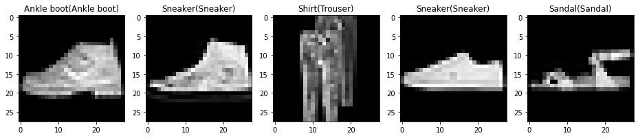

```python
# show 5 examples from X_test for MLP (10k)
display_samples(5, X_test, title='predicted_label', y_dataset = y_test, y_predicted = y_predicted_mlp_10k)
```

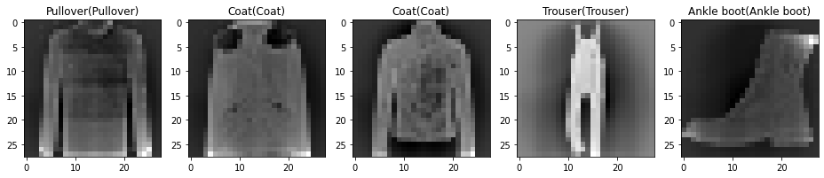

```python
# show 5 examples from X_test_Scaled for MLP (10k)
display_samples(5, X_test_Scaled, title='predicted_label', y_dataset = y_test, y_predicted = y_predicted_mlp_10k_Scaled)
```

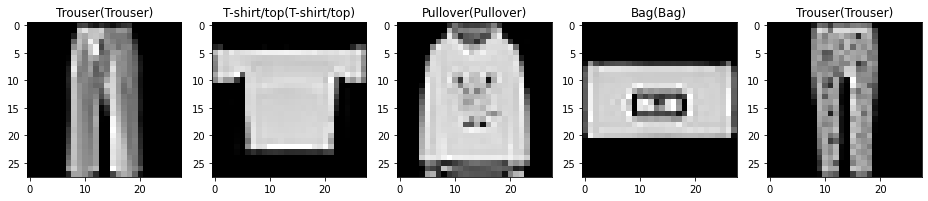

```python
# show 5 examples from X_test_Norm for MLP (10k)
display_samples(5, X_test_Norm, title='predicted_label', y_dataset = y_test, y_predicted = y_predicted_mlp_10k_Norm)
```

#### 2. MLP using 60,000 images

```python
%%time
# measure the amount of time needed to process the cell

# repeat the MLP codes but for the entire dataset

# apply on original data
%timeit -n1 -r1 my_mlp = MLPClassifier(alpha=1, max_iter=1000).fit(X_train, y_train)
y_predicted_mlp = my_mlp.predict(X_test)
print(f"Our MLP prediction using X_train is {np.sum((y_test == y_predicted_mlp))/100}% accurate using 60,000 training samples.\n")

# apply on X_train_Scaled data
%timeit -n1 -r1 my_mlp_Scaled = MLPClassifier(alpha=1, max_iter=1000).fit(X_train_Scaled, y_train)
y_predicted_mlp_Scaled = my_mlp_Scaled.predict(X_test_Scaled)
print(f"Our MLP prediction using X_train_Scaled is {np.sum((y_test == y_predicted_mlp_Scaled))/100}% accurate using 60,000 training samples.\n")

# apply on X_train_Norm data
%timeit -n1 -r1 my_mlp_Norm = MLPClassifier(alpha=1, max_iter=1000).fit(X_train_Norm, y_train)
y_predicted_mlp_Norm = my_mlp_Norm.predict(X_test_Norm)
print(f"Our MLP prediction using X_train_Norm is {np.sum((y_test == y_predicted_mlp_Norm))/100}% accurate using 60,000 training samples.\n")
```

```
3min 57s ± 0 ns per loop (mean ± std. dev. of 1 run, 1 loop each)
Our MLP prediction using X_train is 85.82% accurate using 60,000 training samples.

4min 15s ± 0 ns per loop (mean ± std. dev. of 1 run, 1 loop each)
Our MLP prediction using X_train_Scaled is 87.64% accurate using 60,000 training samples.

3min 39s ± 0 ns per loop (mean ± std. dev. of 1 run, 1 loop each)
Our MLP prediction using X_train_Norm is 84.58% accurate using 60,000 training samples.

CPU times: total: 7min 59s
Wall time: 11min 53s
```

Here, we can similarly see that the more accurate model was the one trained with X_train_Scaled, whereas the model that was trained using X_train_Norm did not perform better than the one that used the original X_train. Furthermore, comparing to our earlier results when we used only 10,000 training images, we can see that for the models trained with X_train and X_train_Scaled, we obtained more accurate predictions using the entire training set containing 60,000 images. my_mlp_Norm, however, did not increase in accuracy when trained with more images.

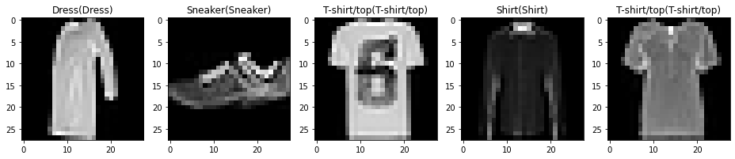

```python
# show 5 examples from X_test for MLP
display_samples(5, X_test, title='predicted_label', y_dataset = y_test, y_predicted = y_predicted_mlp)
```

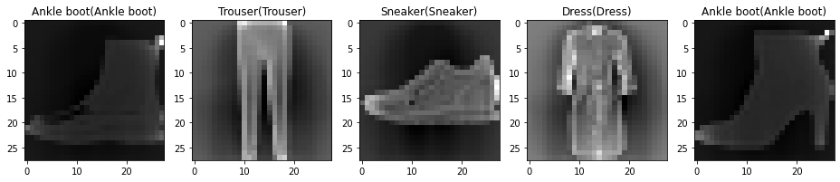

```python
# show 5 examples from X_test_Scaled for MLP
display_samples(5, X_test_Scaled, title='predicted_label', y_dataset = y_test, y_predicted = y_predicted_mlp_Scaled)
```

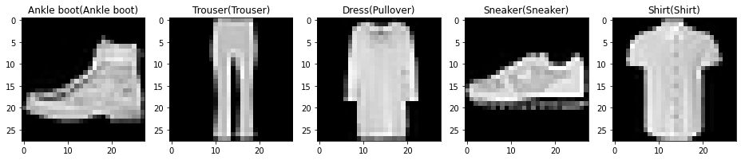

```python
# show 5 examples from X_test_Norm for MLP
display_samples(5, X_test_Norm, title='predicted_label', y_dataset = y_test, y_predicted = y_predicted_mlp_Norm)
```

#### 3. Classification Reports

```python
# compare SVC and MLP performance
from sklearn import metrics
from sklearn.metrics import classification_report, confusion_matrix

# create a function to display classification report and confusion matrix
def display_metrics(classifier, true, predicted):
    '''
    Create a report summary for the given classifier.

    Parameters
    ----------
    classifier: sklearn classifier
        The classifier for which the report will be displayed.

    true: 1D array
        The dataset containing the true labels for the test data.

    predicted: 1D array
        The dataset containing the predicted labels for the test data, obtained from the same user-given classifier.

    '''
    # print the classification report
    print(f"\n---------Classification report for classifier {classifier}-------\n\n"
    f"{classification_report(true, predicted)}")

    # create confusion matrix and display plot
    cm = confusion_matrix(true, predicted)
    plt.figure(figsize = (10,8))
    # obtain the axes values from the label dictionary
    sns.heatmap(cm, annot = True, fmt = '.0f', xticklabels = list(labels.values()), yticklabels = list(labels.values()))
    plt.ylabel('Actual label', fontdict = {'size': 14}); plt.xlabel('Predicted label', fontdict = {'size': 14})
    plt.show()
```

In all three models we have trained above, the ones that used the standardized training data generally performed the best compared to the ones trained on the original and normalized data according to the quick accuracy check, so for sake of simplicity, the classification reports and confusion matrices will compare only those models.

```
---------Classification report for classifier SVC(C=0.025, kernel='linear')-------

              precision    recall  f1-score   support

           0       0.79      0.79      0.79      1000
           1       0.97      0.96      0.96      1000
           2       0.69      0.74      0.71      1000
           3       0.83      0.84      0.84      1000
           4       0.73      0.76      0.75      1000
           5       0.94      0.90      0.92      1000
           6       0.59      0.55      0.57      1000
           7       0.89      0.94      0.91      1000
           8       0.96      0.93      0.94      1000
           9       0.93      0.93      0.93      1000

    accuracy                           0.83     10000
   macro avg       0.83      0.83      0.83     10000
weighted avg       0.83      0.83      0.83     10000
```

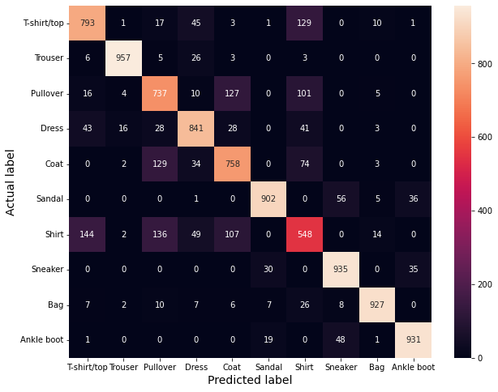

```python
# display classification report and confution matrix for my_svc
display_metrics(my_svc_Scaled, y_test, y_predicted_svc_Scaled)
```

```
---------Classification report for classifier MLPClassifier(alpha=1, max_iter=1000)-------

              precision    recall  f1-score   support

           0       0.76      0.86      0.81      1000
           1       0.97      0.96      0.97      1000
           2       0.74      0.79      0.76      1000
           3       0.90      0.82      0.86      1000
           4       0.76      0.78      0.77      1000
           5       0.94      0.93      0.93      1000
           6       0.69      0.61      0.65      1000
           7       0.92      0.94      0.93      1000
           8       0.96      0.95      0.95      1000
           9       0.94      0.94      0.94      1000

    accuracy                           0.86     10000
   macro avg       0.86      0.86      0.86     10000
weighted avg       0.86      0.86      0.86     10000
```

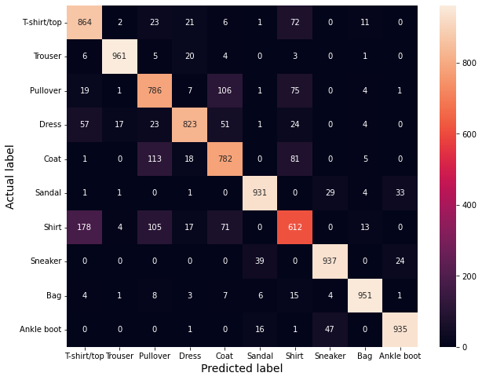

```python
# display classification report and confution matrix for my_mlp_10k
display_metrics(my_mlp_10k_Scaled, y_test, y_predicted_mlp_10k_Scaled)
```

```
---------Classification report for classifier MLPClassifier(alpha=1, max_iter=1000)-------

              precision    recall  f1-score   support

           0       0.81      0.85      0.83      1000
           1       0.99      0.96      0.97      1000
           2       0.79      0.80      0.79      1000
           3       0.85      0.91      0.88      1000
           4       0.79      0.81      0.80      1000
           5       0.97      0.94      0.95      1000
           6       0.73      0.63      0.68      1000
           7       0.91      0.97      0.94      1000
           8       0.96      0.97      0.97      1000
           9       0.97      0.93      0.95      1000

    accuracy                           0.88     10000
   macro avg       0.88      0.88      0.88     10000
weighted avg       0.88      0.88      0.88     10000
```

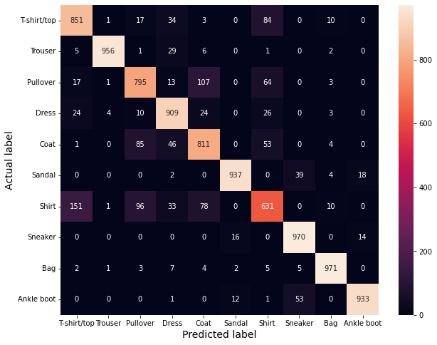

```python
# display classification report and confution matrix for my_mlp
display_metrics(my_mlp_Scaled, y_test, y_predicted_mlp_Scaled)
```

```python
%%html
<style>
table {float:left}
</style>
```

### ML Performance Comparsion:

- Comparing the **accuracy scores** of our svc classifier and mlp classifier using 10,000 training images, we can see that the scores for our mlp model is more accurate than than our svc model accross all training sets. We can similarly see that training our model using 60,000 images yeilded more accurate results compared to training it with the smaller dataset, with the exception of the normalized training data. In conclusion, our most accurate model is the mlp model trained on the entire standardized training set.

| Training Data | svc (10k) | mlp (10k) | mlp (60k) |
| --- | --- | --- | --- |
| X_train | 79.64% | 83.35% | 85.82% |
| X_train_Scaled | 83.29% | 85.82% | 87.64% |
| X_train_Norm | 83.85% | 84.97% | 84.58% |

| Training Data | svc (10k) | mlp (10k) | mlp (60k) |
| --- | --- | --- | --- |
| X_train | 55.4 s | 46.3 s | 3:57 m |
| X_train_Scaled | 14.9 s | 38.7 s | 4:15 m |
| X_train_Norm | 15.8 s | 31.6 s | 3:39 m |

#### 5. Please apply a Sobel edge detector on the above dataset images (both training and testing), then train the same MLP classifier as above (on the whole new trianing set), show the prediction results of 5 samples from the (new) test set, with the "prediction (ground-truth label)" as title for each sample, and also report the main classification matrics.

#### Similarly, apply a bilateral filter (neighborhood diameter 9 and both sigma for color and space set to 85) to the original dataset images (both training and testing), then train the same MLP classifier, show the prediction, and the metrics, same as above. Compare the difference between the original-image-based classification, edge-based classification, and this filtered-image-based classification.

```python
import cv2
print (f"numpy version: {np.__version__}, cv2 version: {cv2.__version__}")
```

```
numpy version: 1.26.1, cv2 version: 4.8.1
```

### 1. Sobel Filter

```python
# create a new training/test set containing X_train/X_test images but with the sobel edge detection applied on each one

# initialize an empty array with the same shape as the original array to store the output
X_train_sobel = np.empty(X_train.shape)
X_test_sobel = np.empty(X_test.shape)

# set the desired sobel parameters
ddepth = cv2.CV_64F  # 64-bit float output
dx = 1  # first-order derivative in x-direction
dy = 0  # no derivative in y-direction

# apply sobel edge detection on X_train
for image in range(X_train.shape[0]): # for each row/image..
    sobel = cv2.Sobel(X_train[image,:].reshape(28,28), ddepth, dx, dy) # ..reshape and apply the sopel filer..
    X_train_sobel[image] = sobel.reshape(784)# ..unshape and save row back to output array

# apply sobel edge detection on X_test
for image in range(X_test.shape[0]):
    sobel = cv2.Sobel(X_test[image,:].reshape(28,28), ddepth, dx, dy)
    X_test_sobel[image] = sobel.reshape(784)
```

```python
# create a new training/test set containing _Scaled images but with the sobel edge detection applied on each one

# initialize an empty array with the same shape as the original array to store the output
X_train_Scaled_sobel = np.empty(X_train_Scaled.shape)
X_test_Scaled_sobel = np.empty(X_test_Scaled.shape)

# apply sobel edge detection on X_train_Scale using the same parameters set in the cell above
for image in range(X_train_Scaled.shape[0]):
    sobel = cv2.Sobel(X_train_Scaled[image,:].reshape(28,28), ddepth, dx, dy)
    X_train_Scaled_sobel[image] = sobel.reshape(784)

# apply sobel edge detection on X_test_Scale using the same parameters set in the cell above
for image in range(X_test_Scaled.shape[0]):
    sobel = cv2.Sobel(X_test_Scaled[image,:].reshape(28,28), ddepth, dx, dy)
    X_test_Scaled_sobel[image] = sobel.reshape(784)
```

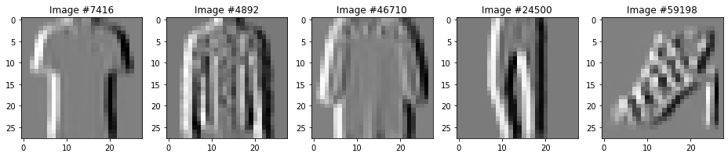

```python
# show 5 examples from the X_train_sobel
display_samples(5, X_train_sobel, title='row')
```

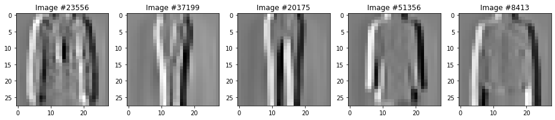

```python
# show 5 examples from the X_train_Scaled_sobel
display_samples(5, X_train_Scaled_sobel, title='row')
```

```python
# repeat the MLP code here on X_train_sobel

my_mlp_sobel = MLPClassifier(alpha=1, max_iter=1000).fit(X_train_sobel, y_train)
y_predicted_mlp_sobel = my_mlp_sobel.predict(X_test_sobel)
print(f"Our MLP prediction is {np.sum((y_test == y_predicted_mlp_sobel))/100}% accurate using 60,000 sobel training samples.")
```

```
Our MLP prediction is 84.33% accurate using 60,000 sobel training samples.
```

```python
# repeat the MLP code here on X_train_Scaled_sobel

my_mlp_Scaled_sobel = MLPClassifier(alpha=1, max_iter=1000).fit(X_train_Scaled_sobel, y_train)
y_predicted_mlp_Scaled_sobel = my_mlp_Scaled_sobel.predict(X_test_Scaled_sobel)
print(f"Our MLP prediction is {np.sum((y_test == y_predicted_mlp_Scaled_sobel))/100}% accurate using 60,000 sobel training samples.")
```

```
Our MLP prediction is 87.5% accurate using 60,000 sobel training samples.
```

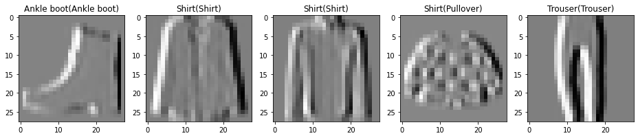

```python
# show 5 examples from X_test_sobel
display_samples(5, X_test_sobel, title='predicted_label', y_dataset = y_test, y_predicted = y_predicted_mlp_sobel)
```

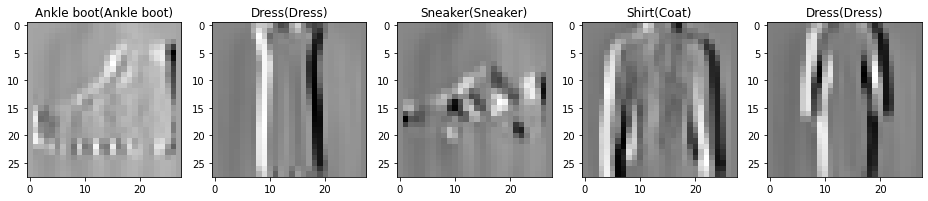

```python
# show 5 examples from X_test_Scaled_sobel
display_samples(5, X_test_Scaled_sobel, title='predicted_label', y_dataset = y_test, y_predicted = y_predicted_mlp_Scaled_sobel)
```

```
---------Classification report for classifier MLPClassifier(alpha=1, max_iter=1000)-------

              precision    recall  f1-score   support

           0       0.78      0.82      0.80      1000
           1       0.97      0.96      0.97      1000
           2       0.80      0.68      0.73      1000
           3       0.86      0.86      0.86      1000
           4       0.73      0.79      0.76      1000
           5       0.97      0.91      0.94      1000
           6       0.58      0.60      0.59      1000
           7       0.88      0.96      0.92      1000
           8       0.93      0.94      0.94      1000
           9       0.96      0.91      0.93      1000

    accuracy                           0.84     10000
   macro avg       0.85      0.84      0.84     10000
weighted avg       0.85      0.84      0.84     10000
```

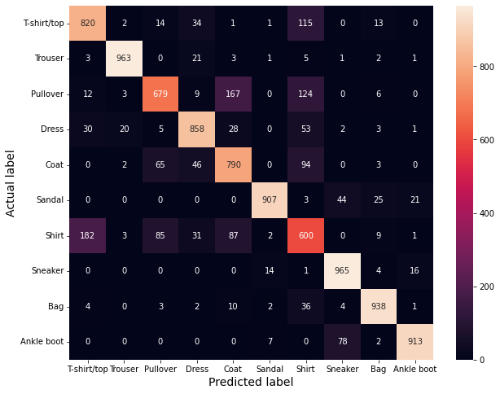

```python
# display classification report and confution matrix for my_mlp_sobel
display_metrics(my_mlp_sobel, y_test, y_predicted_mlp_sobel)
```

```
---------Classification report for classifier MLPClassifier(alpha=1, max_iter=1000)-------

              precision    recall  f1-score   support

           0       0.87      0.80      0.83      1000
           1       0.98      0.96      0.97      1000
           2       0.82      0.78      0.80      1000
           3       0.86      0.90      0.88      1000
           4       0.79      0.82      0.80      1000
           5       0.96      0.94      0.95      1000
           6       0.68      0.71      0.69      1000
           7       0.90      0.97      0.93      1000
           8       0.94      0.96      0.95      1000
           9       0.96      0.92      0.94      1000

    accuracy                           0.88     10000
   macro avg       0.88      0.88      0.88     10000
weighted avg       0.88      0.88      0.88     10000
```

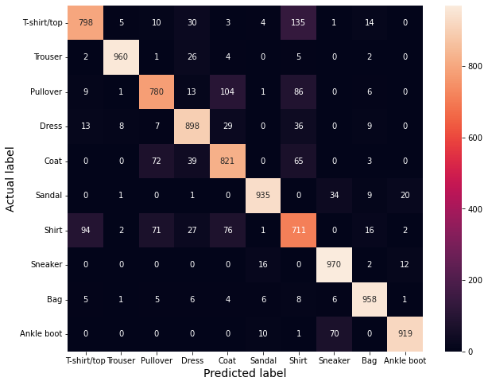

```python
# display classification report and confution matrix for my_mlp_Scaled_sobel
display_metrics(my_mlp_Scaled_sobel, y_test, y_predicted_mlp_Scaled_sobel)
```

### 2. Bilateral Filter

```python
# create a new training/test set containing X_train/X_test images but with the bilateral filter applied on each one

# initialize an empty array with the same shape as the original array to store the output
X_train_bilat = np.empty(X_train.shape)
X_test_bilat = np.empty(X_test.shape)

# apply bilateral filter on X_train
for image in range(X_train.shape[0]): # for every row/image.
    bilat = cv2.bilateralFilter(X_train[image,:].reshape(28,28),9,85,85) #.. reshape and apply bilaterl filer..
    X_train_bilat[image] = bilat.reshape(784) #..unshape and save in output array

# apply sobel edge detection on X_test
for image in range(X_test.shape[0]):
    bilat = cv2.bilateralFilter(X_test[image,:].reshape(28,28),9,85,85)
    X_test_bilat[image] = bilat.reshape(784)
```

```python
# create a new training/test set containing _ images but with bilatral  applied on each one

# initialize an empty array with the same shape as the original array to store the output
X_train_Scaled_bilat = np.empty(X_train_Scaled.shape)
X_test_Scaled_bilat = np.empty(X_test_Scaled.shape)

# apply bilateral filter on X_train
for image in range(X_train_Scaled.shape[0]): # for every row/image..
    bilat = cv2.bilateralFilter(X_train_Scaled[image,:].reshape(28,28).astype(np.float32),9,85,85) #.. reshape and apply bilaterl filer..
    X_train_Scaled_bilat[image] = bilat.reshape(784) #..unshape and save in output array

# apply sobel edge detection on X_test
for image in range(X_test_Scaled.shape[0]):
    bilat = cv2.bilateralFilter(X_test_Scaled[image,:].reshape(28,28).astype(np.float32),9,85,85)
    X_test_Scaled_bilat[image] = bilat.reshape(784)
```

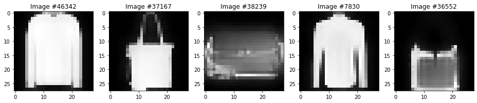

```python
# show 5 examples from X_train_bilat
display_samples(5, X_train_bilat, title='row')
```

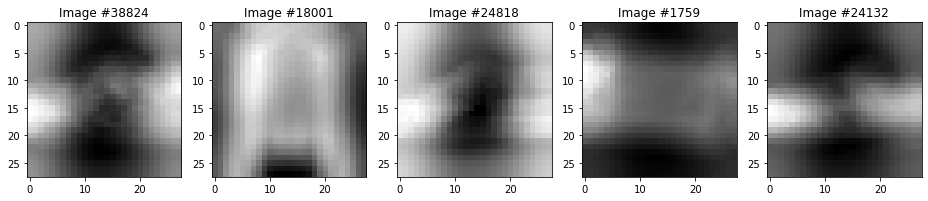

```python
# show 5 examples from X_train_Scaled_bilat
display_samples(5, X_train_Scaled_bilat, title='row')
```

```python
# repeat the MLP code here on X_train_bilat

my_mlp_bilat = MLPClassifier(alpha=1, max_iter=1000).fit(X_train_bilat, y_train)
y_predicted_mlp_bilat = my_mlp_bilat.predict(X_test_bilat)
print(f"Our MLP prediction is {np.sum((y_test == y_predicted_mlp_bilat))/100}% accurate using 60,000 sobel training samples.")
```

```
Our MLP prediction is 84.87% accurate using 60,000 sobel training samples.
```

```python
# repeat the MLP code here on X_train_Scaled_bilat

my_mlp_Scaled_bilat = MLPClassifier(alpha=1, max_iter=1000).fit(X_train_Scaled_bilat, y_train)
y_predicted_mlp_Scaled_bilat = my_mlp_Scaled_bilat.predict(X_test_Scaled_bilat)
print(f"Our MLP prediction is {np.sum((y_test == y_predicted_mlp_Scaled_bilat))/100}% accurate using 60,000 sobel training samples.")
```

```
Our MLP prediction is 84.45% accurate using 60,000 sobel training samples.
```

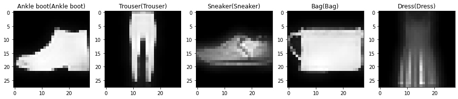

```python
# show 5 examples from X_test_bilat
display_samples(5, X_test_bilat, title='predicted_label', y_dataset = y_test, y_predicted = y_predicted_mlp_bilat)
```

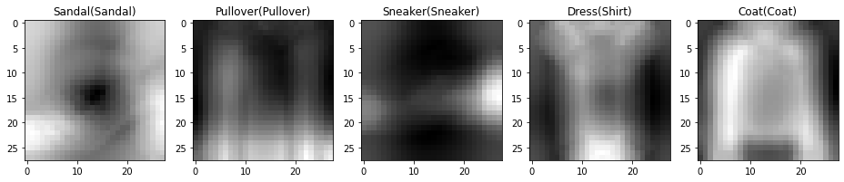

```python
# show 5 examples from X_test_Scaled_bilat
display_samples(5, X_test_Scaled_bilat, title='predicted_label', y_dataset = y_test, y_predicted = y_predicted_mlp_Scaled_bilat)
```

```
---------Classification report for classifier MLPClassifier(alpha=1, max_iter=1000)-------

              precision    recall  f1-score   support

           0       0.77      0.84      0.80      1000
           1       0.95      0.97      0.96      1000
           2       0.76      0.73      0.74      1000
           3       0.82      0.88      0.85      1000
           4       0.81      0.69      0.75      1000
           5       0.95      0.95      0.95      1000
           6       0.61      0.59      0.60      1000
           7       0.90      0.96      0.93      1000
           8       0.96      0.96      0.96      1000
           9       0.97      0.93      0.95      1000

    accuracy                           0.85     10000
   macro avg       0.85      0.85      0.85     10000
weighted avg       0.85      0.85      0.85     10000
```

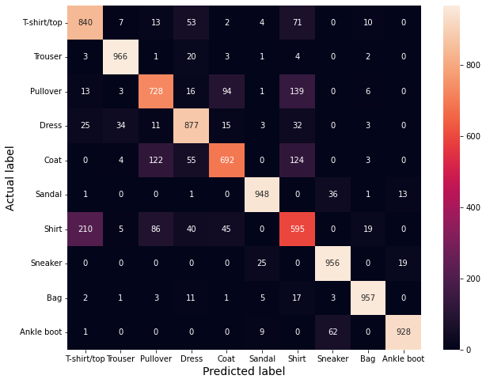

```python
# display classification report and confution matrix for my_mlp_bilat
display_metrics(my_mlp_bilat, y_test, y_predicted_mlp_bilat)
```

```
---------Classification report for classifier MLPClassifier(alpha=1, max_iter=1000)-------

              precision    recall  f1-score   support

           0       0.79      0.80      0.79      1000
           1       0.92      0.96      0.94      1000
           2       0.71      0.80      0.75      1000
           3       0.81      0.87      0.84      1000
           4       0.78      0.75      0.76      1000
           5       0.93      0.92      0.92      1000
           6       0.69      0.53      0.60      1000
           7       0.92      0.91      0.91      1000
           8       0.95      0.97      0.96      1000
           9       0.93      0.95      0.94      1000

    accuracy                           0.84     10000
   macro avg       0.84      0.84      0.84     10000
weighted avg       0.84      0.84      0.84     10000
```

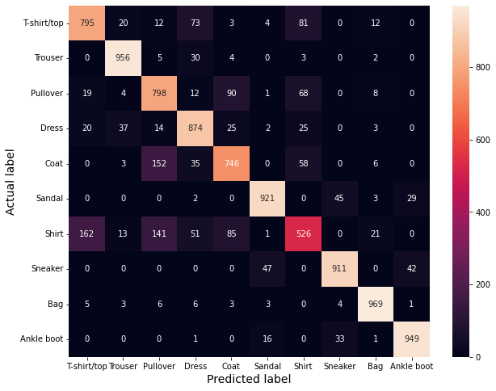

```python
# display classification report and confution matrix for my_mlp_bilat
display_metrics(my_mlp_Scaled_bilat, y_test, y_predicted_mlp_Scaled_bilat)
```

- Comparing the **accuracies** of our mlp model using both X_train and X_train_Scaled in three different conditions: without any image modification, with sobel edge detection and with bilateral filtering, we can see that the most accurate model remains that of the standardized data without any modifications to it. Applying the sobel edge detection on the standardized data seems to not affect the accuracy much, but applying the bilateral filter led to decrease in accuracy. As for using X_train on our mlp model, both modifications lowered the accuracy compared to no image modification.

| MLP - data used | Non-modified | Sobel Edge Detection | Bilateral Filter |
| --- | --- | --- | --- |
| X_train | 85.82% | 84.33% | 84.87% |
| X_train_Scaled | 87.64% | 87.50% | 84.45% |